# Simulation showcase

Gilles Lijnzaad

2026-04-07

In this document, I demonstrate the behavior of the simulation by varying the parameter settings and visualizing the resulting behavior. The full simulation code can be found in [sim.R](https://gilleslijnzaad.github.io/climate-RL-modeling/all_utils.html#simR), and all plot-related functions come from [plot_utils.R](https://gilleslijnzaad.github.io/climate-RL-modeling/all_utils.html#plot_utilsR).

# 1 Standard settings

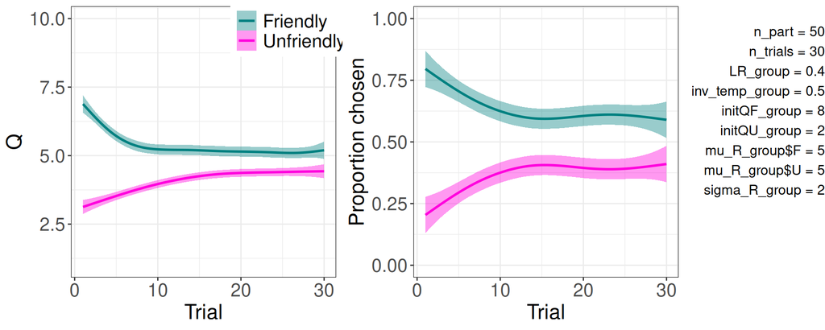

```r
rm(list = ls())
# setwd("R_simulation/")

sim <- new.env()
source("sim.R", local = sim)  # access functions using sim$fun()

params_std <- list(
  n_part = 50,
  n_trials = 30,
  LR_group = 0.4,
  inv_temp_group = 0.5,
  initQF_group = 8,
  initQU_group = 2,
  mu_R_group = list(F = 5, U = 5),
  sigma_R_group = 2
)
plot <- new.env()
source("../plot_utils.R", local = plot)  # access functions using plot$fun()

dat <- sim$run_std(params_std)
plot$sim_plots(dat, params_std)
```

## 1.1 Varying learning rate

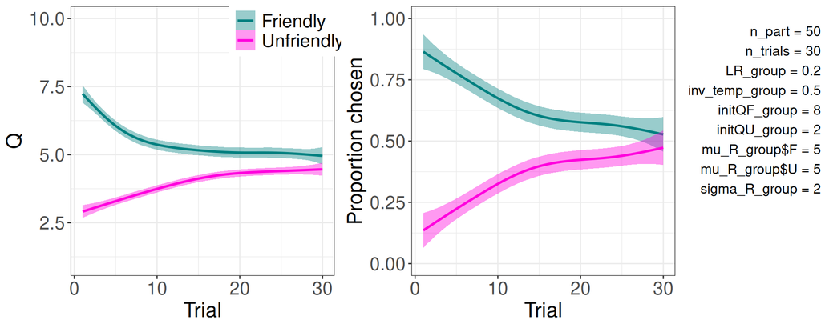

```r
params <- modifyList(params_std, list(LR_group = 0.2))
dat <- sim$run_std(params)
plot$sim_plots(dat, params)
```

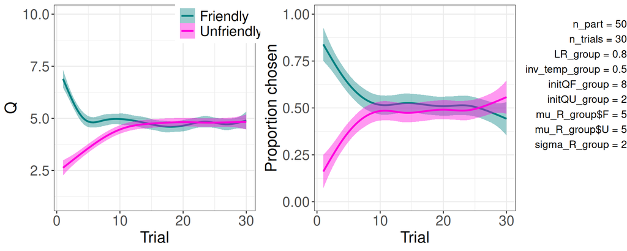

```r
params <- modifyList(params_std, list(LR_group = 0.8))
dat <- sim$run_std(params)
plot$sim_plots(dat, params)
```

## 1.2 Varying inverse temperature

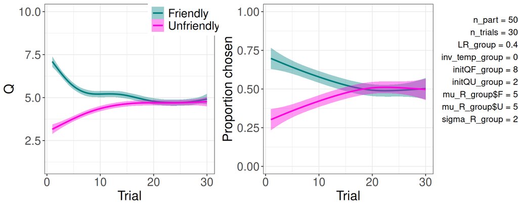

```r
params <- modifyList(params_std, list(inv_temp_group = 0))
dat <- sim$run_std(params)
plot$sim_plots(dat, params)
```

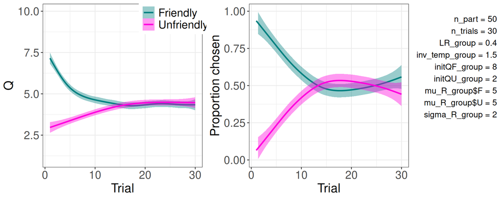

```r
params <- modifyList(params_std, list(inv_temp_group = 1.5))
dat <- sim$run_std(params)
plot$sim_plots(dat, params)
```

# 2 Confirmation bias

The first differentiation is whether bias occurs at the level of learning (*LRN*) or the level of rating (*RTN*).

## 2.1 Learning: *LRN*

We assume that the relationship between confirmation and learning rate (LR) is either discrete (discr) or continuous (cont).

### 2.1.1 Discrete: *discr*

Confirmatory and disconfirmatory outcomes have separate learning rates, where LR_conf > LR_disconf.

#### 2.1.1.1 Close to belief: *approx*

$$LR =
\begin{cases}
{LR}_\text{conf} &\text{if}\ \left| R - \text{belief} \right|
\leq \text{margin} \\
LR_\text{disconf} &\text{else}
\end{cases}$$
If the difference between the rating and belief is lesser than or equal to the defined margin, the outcome is treated as confirmatory. Else disconfirmatory. Name `approx` comes from the LaTeX code for the “approximately equal to” sign: $R \approx \text{belief}$.

```r
params_LRN_discr <- list(
  n_part = 50,
  n_trials = 30,
  LRs_group = list(conf = 0.8, disconf = 0.2),
  inv_temp_group = 0.5,
  initQ_group = list(F = 8, U = 2),
  mu_R_group = list(F = 5, U = 5),
  sigma_R_group = 2,
  margin_group = 2
)
```

##### *stat*

Beliefs are the static “outside-world values” that one has before starting the experiment.

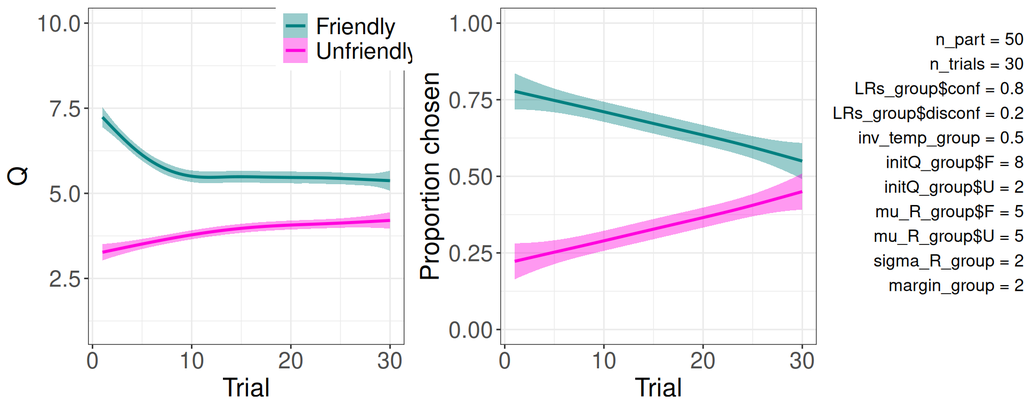

```r
dat <- sim$run_LRN_discr(params_LRN_discr, sim$LR_approx, "stat")
plot$sim_plots(dat, params_LRN_discr)
```

##### *dyn*

Beliefs are the dynamic “within-experiment values”.

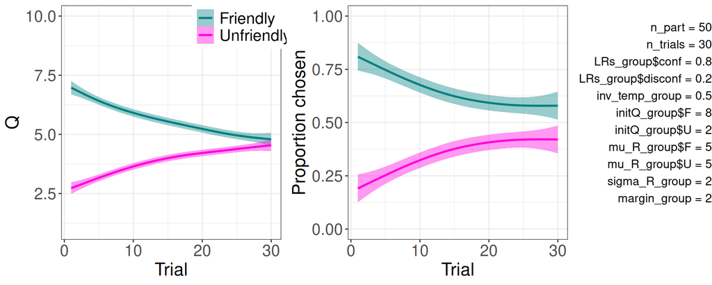

```r
dat <- sim$run_LRN_discr(params_LRN_discr, sim$LR_approx, "dyn")
plot$sim_plots(dat, params_LRN_discr)
```

#### 2.1.1.2 Greater than or equal to belief: *geq*

##### *stat*

Beliefs are the static “outside-world values” that one has before starting the experiment.

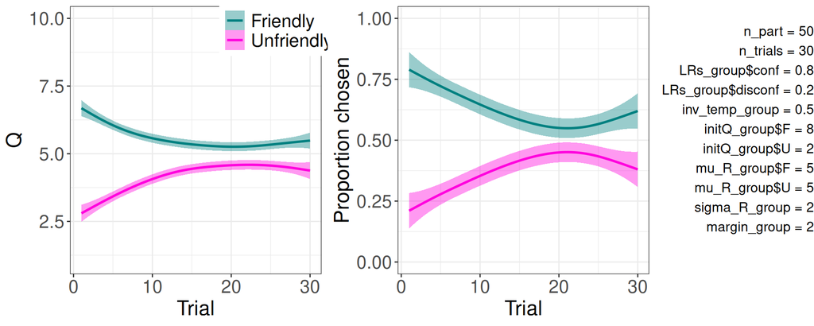

```r
dat <- sim$run_LRN_discr(params_LRN_discr, sim$LR_geq, "stat")
plot$sim_plots(dat, params_LRN_discr)
```

##### *dyn*

Beliefs are the dynamic “within-experiment values”.

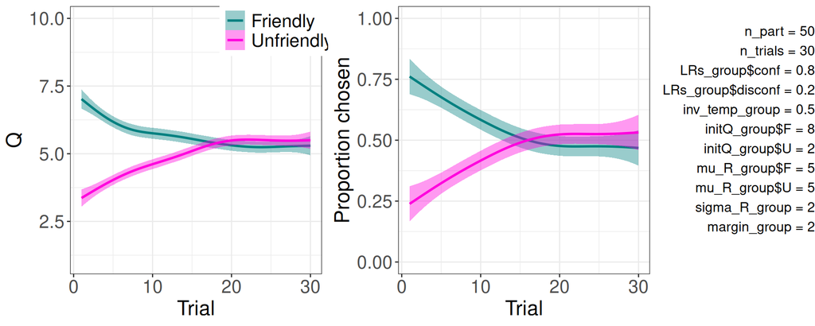

```r
dat <- sim$run_LRN_discr(params_LRN_discr, sim$LR_geq, "dyn")
plot$sim_plots(dat, params_LRN_discr)
```

### 2.1.2 Continuous: *cont*

The learning rate relates to the deviation from belief in a continuous way, with limits at 0 and predefined LR_max. The relationship is defined by LR_slope.

$$\begin{alignat*}{2}
LR = LR_{\max} \cdot & LR'\\
& LR' =
\begin{cases}
1 &\text{if}\ R +
\text{margin} \geq \text{belief} \\
LR_\text{slope} \cdot \text{diff} + 1 &\text{else}
\end{cases}\\
\text{with } & LR' \in [0, 1]
\end{alignat*}$$

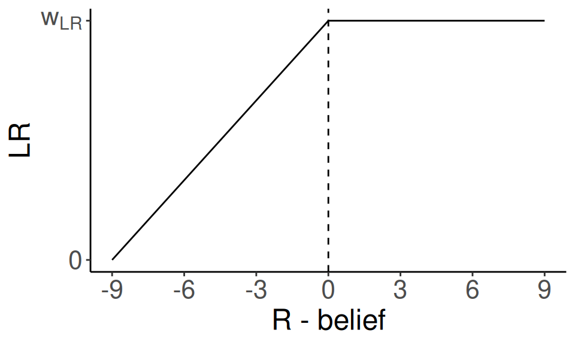

```r
dummy <- data.frame(
  diff = c(-9, 0, 9),
  LR_prime = c(0, 1, 1)
)
ggplot(dummy) +
  geom_line(aes(x = diff, y = LR_prime)) +
  geom_vline(aes(xintercept = 0), lty = 2) +
  scale_x_continuous(breaks = seq(-9, 9, 3)) +
  scale_y_continuous(breaks = c(0, 1), labels = c("0", expression(w[LR]))) +
  labs(x = "R - belief", y = "LR") +
  plot$my_theme_classic
```

#### *stat*

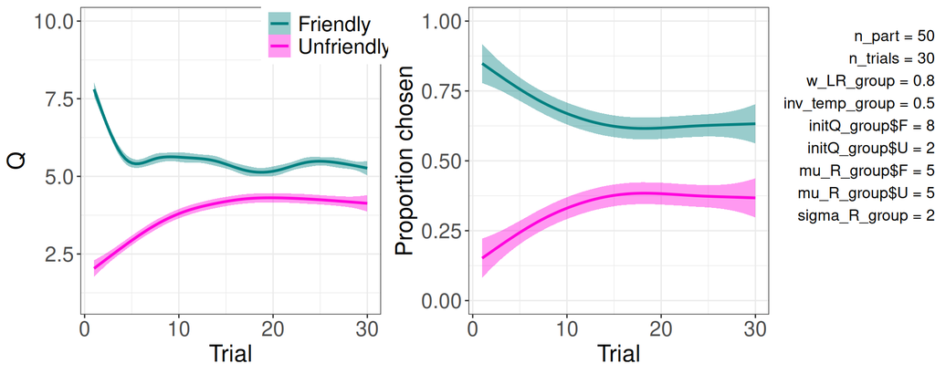

```r
params_LRN_cont <- list(
  n_part = 50,
  n_trials = 30,
  w_LR_group = 0.8,
  inv_temp_group = 0.5,
  initQ_group = list(F = 8, U = 2),
  mu_R_group = list(F = 5, U = 5),
  sigma_R_group = 2
)

dat <- sim$run_LRN_cont(params_LRN_cont, "stat")
plot$sim_plots(dat, params_LRN_cont)
```

#### *dyn*

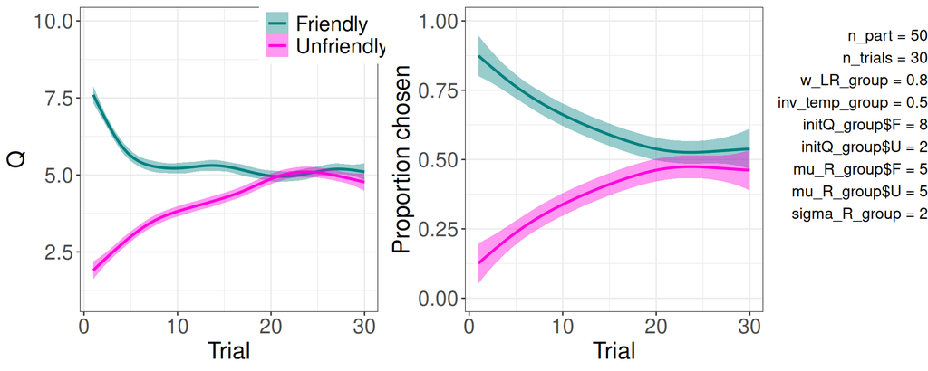

```r
dat <- sim$run_LRN_cont(params_LRN_cont, "dyn")
plot$sim_plots(dat, params_LRN_cont)
```

## 2.2 Rating: *RTN*